# TP 2 : régions de crédibilité

1. Pour ce $TP$, on va travailler avec les mêmes données que pour le premier $TP$ :

```r
data = read.csv("aide_au_developpement.csv",sep = ";")
type = (data$Groupe.de.produit=="Subvention")
```

- Comme pour le premier TP, on considèrera le modèle suivant :
  $$\begin{align*}
  X_i \mid \theta& \sim_{i.i.d.} \mathcal{B}er(\theta)
  \end{align*}$$
- On a déjà vu en cours que la loi Beta est conjugué pour le modèle Bernoulli. On fixera ici les hyperparamètre du prior arbitrairement.
  $$\begin{align*}
  \\ \theta &\sim Beta(a,b)
  \\ (a, b) &= \Big(\frac12,\frac12\Big)
  \end{align*}$$
- La propriété de conjugaison a été montrée en cours, et on a
  $$\theta \mid x_1, \cdots x_n\sim Beta\Big(a+\sum_{i = 1}^n x_i, b+n-\sum_{i = 1}^n x_i\Big)$$

On peut donc simplement écrire

```r
update = function(a,b,x){
  return(c(apost = a+sum(x),bpost = b+length(x)-sum(x)))
}
```

- Cette fonction est immédiate

```r
region_asym = function(apost,bpost,alpha1,alpha2){
  q1 = qbeta(alpha1,apost,bpost)
  q2 = qbeta(1-alpha2,apost,bpost)
  return(c(q1 = q1,q2 = q2))
}
```

- Pour celle ci, il n’y a qu’à parcourir des valeurs entre $0$ et $\alpha$ :

```r
region_vol_min = function(apost,bpost,alpha){
  alpha1_seq = seq(0,alpha,length = 1000)
  qseq = sapply(alpha1_seq,function(a,ap,bp,alpha){return(region_asym(ap,bp,a,alpha-a))},ap = apost,bp = bpost,alpha = alpha)
  vol = qseq[2,]-qseq[1,]
  return(qseq[,which.min(vol)])
}
```

3. Cette fois, on souhaite travailler avec le posterior évalué sur une grille
- On va donc choisir une grille pour travailler

```r
a = b = 1/2##on fixe les hyperparamètres du prior
theta_vec = seq(0.001,0.999,length = 10000)
hyperparam_post = update(a,b,type)
y = dbeta(theta_vec,hyperparam_post[1],hyperparam_post[2])
```

- On peut ensuite construire la fonction qui à un seuil donne la probabilité de la région HPD associée à ce seuil

```r
region_HPD = function(s,theta_vec,y){
  id_up = (y>s)
  dx = diff(theta_vec[1:2])##pas d'intégration
  prob = sum(y[id_up]*dx)
  q1 =min(theta_vec[id_up])
  q2 = max(theta_vec[id_up])
  return(c(prob = prob,q1 = q1,q2 = q2))
}
```

- On n’a plus qu’à parcourir des seuils. On pourrait tout à fait faire une boucle pour parcourir plusieurs seuils (solution la plus évidente), mais on propose plus bas de classer les $y$ par valeurs décroissantes, et de calculer la probabilité de toutes les régions HPD en même temps.

```r
region_HPD_alpha = function(alpha,hyperparam_post){
  theta_vec = seq(0.001,0.999,length = 10000)
  y = dbeta(theta_vec,hyperparam_post[1],hyperparam_post[2])
  dx = diff(theta_vec[1:2])##pas d'intégration
  y_sort = sort(y,decreasing = T,index.return = T)
  prob_high = cumsum(y_sort$x*dx)## cela donne, pour chaque seuil possible la proba de la région HPD correspondante, sans avoir besoin d'appliquer la fonction précédente
  id_min = which.min( (prob_high-(1-alpha))**2  )##on choppe l'identifiant du seuil
  seuil = y_sort$x[id_min]##on en déduit le seuil
  ##là, on peut soit utiliser y_sort pour en déduire la région HPD, soit appliquer la fonction précédente ce qui permet de vérifier un peu que l'on se s'est pas trompé
  output = region_HPD(seuil,theta_vec,y)
  return(output)
}
```

4. Enfin, on voudrait être capable de faire la même chose, seulement avec une simulation sous le posterior (et une évaluation en celle -ci).
- On commence donc par simuler sous le posterior

```r
theta_sim = rbeta(10000,hyperparam_post[1],hyperparam_post[2])
z = runif(10)*dbeta(theta_sim,hyperparam_post[1],hyperparam_post[2])## On ajoute un facteur multiplicatif aléatoire, pour illustrer que l'on connait le posterior seulement à constante près
```

- `A partir de là, on peut construire la région HPD $(1-\alpha)$-crédible, en remarquant que pour constuire une région $(1-\alpha)$-crédibles à partir de $\theta_{sim}$, il suffit de constuire une région contenant une proportion $1-\alpha$ de l’échantillon. De plus, la région HPD est obtenue comme précédemment en parcourant les seuils, il suffit donc de faire comme suit :

```r
region_HPD_sim= function(alpha,theta_sim,z){
  z_sort = sort(z,decreasing = T)
  theta_in_region = theta_sim[z>z_sort[1+(1-alpha)*length(z)]]## En général, on pourrait renvoyer juste ça, ou le vecteur indiquant si les theta simulés sont dans la région de crédibilité
  return(c(q1= min(theta_in_region),q2 = max(theta_in_region)     ))##ici, on assume de nouveau que la région est connexe
}
```

5. Enfin, on peut comparer les 3 méthodes

```r
alpha = 0.05
region_vol_min(hyperparam_post[1],hyperparam_post[2],alpha)
```

```
       q1        q2
0.7324353 0.7740808
```

```r
region_HPD_alpha(alpha,hyperparam_post)
```

```
     prob        q1        q2
0.9493092 0.7325074 0.7739285
```

```r
region_HPD_sim(alpha,theta_sim,z)
```

```
       q1        q2
0.7216350 0.7840026
```

On remarque que la dernière méthode semble la moins précise. En effet, par définition de la région de crédibilité, une proportion d’environ $1-\alpha$ de l’échantillon simulé est à l’intérieur de cette région, et peu seront à la frontière. En réalité, cela revient à parcourir les quantiles empiriques de cet échantillon, et cette estimation seule à un coût en terme de variabilité.

```r
IC = mean(type)+qnorm(0.975)*sqrt(mean(type)*(1-mean(type))/length(type))*c(-1,1)
print(IC)
```

```
[1] 0.7326606 0.7743388
```

Sur cet exemple, on est très proche de l’intervalle fréquentiste. En réalité, ce sera une propriété asymptotiques de telles régions, conséquence du théorème de Bernstein von Mises, que l’on verra rapidement à la fin du cours.

Enfin, on peut représenter la région de crédibilité pour fixer les idées.

```r
R = region_vol_min(hyperparam_post[1],hyperparam_post[2],alpha)
xseq = seq(R[1]-0.03,R[2]+0.03,length=1000)
yseq = dbeta(xseq,hyperparam_post[1],hyperparam_post[2])
plot(xseq,yseq,xlab = "p",ylab = "Densité",main = "Région de crédibilité",type = "l")
id_in_region = (xseq>R[1])&(xseq<R[2])
abline(h= 0)
```

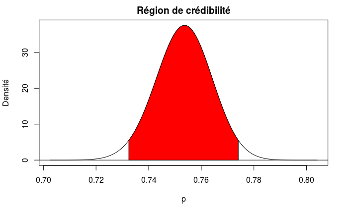

```r
polygon(c(xseq[id_in_region],rev(xseq[id_in_region])),c(yseq[id_in_region],rep(0,length(yseq[id_in_region]))),col ="red")
```